# Redundancy Analysis (RDA)

Candidate SNP identification & variance partitioning

Author

Juliette Archambeau & Adélaïde Theraroz

Published

July 27, 2023

# 1 Introduction

Most analyses conducted in this document are based on:

- Forester et al. (2018) and the associated [vignette](https://popgen.nescent.org/2018-03-27_RDA_GEA.html).
- Capblancq and Forester (2021) and the associated [Github repository](https://github.com/Capblancq/RDA-landscape-genomics).

RDA can either be performed on *individual-based genotypes* (i.e. allele counts 0, 1 or 2) or *population-based allele frequencies*. Forester et al. (2018) suggests to use individual-based allele counts when most samples have individual coordinates and individual environment data (which depends on the resolution of the environmental data across the study area). In the present study, we use *population-level allele frequencies* as several genotypes were collected at each sampling site (i.e. source population) and therefore experience the same climatic conditions. Moreover, the sample sizes vary across populations.

# 2 The data

## 2.1 Climatic data

We load the population-specific climatic information for the climatic variables of interest.

```r
# set of climatic variables that we are going to use
clim_var <- c("bio1","bio12","bio15","bio3","bio4","SHM")

# loading climatic data and mean-standardizing them
df <- readRDS(here("data/climatic_data/reference_climate_population_locations.rds")) %>%
  dplyr::mutate(across(where(is.numeric), ~ (. - mean(.)) / sd(.))) %>%
  arrange(pop) # to be sure that climatic data and genomic data are in the same order
```

```r
# Define the colors associated with each climatic variable for the following visualizations
color_clim_var <- sample(c('#1f78b4','#a6cee3','#6a3d9a','#e31a1c','#33a02c','#ffff33','#fb9a99',
                    '#FF7FE6', '#FFB675', '#51FF74','#B4FF32'), length(clim_var), replace=F) %>% #
  setNames(clim_var)
```

## 2.2 Population coordinates and Moran eigen’s vectors

We use distance-based Moran’s Eigenvector Maps (dbMEMs) for the variance partitioning, as done in Capblancq et al. (2023).

```r
df <- read.csv(here("data/selected_populations_GOanalyses.csv")) %>%
  dplyr::select(pop,contains("ude")) %>%
  bind_cols(dbmem(.[,c("longitude","latitude")])) %>%  # we add the distance-based Moran’s Eigenvector Maps (dbMEMs)
  right_join(df,., by="pop")
```

## 2.3 Genomic data

### 2.3.1 Population-level allele frequencies

```r
# Population-based allele frequencies
# ===================================
geno_pop <- read_csv(here("data/genomic_data/imputed_allele_frequencies_withoutmaf.csv")) %>%
  column_to_rownames("pop")
kable_mydf(geno_pop[1:10,1:10] %>% round(3), boldfirstcolumn = T)
```

|  | Affx-979041050 | Affx-979041051 | Affx-979041053 | Affx-979041054 | Affx-979041055 | Affx-979041057 | Affx-979041058 | Affx-979041059 | Affx-979041060 | Affx-979041061 |
| --- | --- | --- | --- | --- | --- | --- | --- | --- | --- | --- |
| ABA | 0.02 | 0.02 | 0.43 | 0.91 | 0.00 | 0.00 | 0.02 | 0.00 | 0.00 | 0.02 |
| ADE | 0.05 | 0.60 | 1.00 | 0.10 | 0.19 | 0.00 | 0.71 | 0.00 | 0.86 | 0.71 |
| AHI | 0.00 | 0.11 | 0.32 | 0.14 | 0.04 | 0.00 | 0.52 | 0.02 | 0.09 | 0.00 |
| ALT | 0.00 | 0.06 | 0.00 | 0.12 | 0.00 | 0.00 | 0.19 | 0.06 | 0.00 | 0.00 |
| ANI | 0.07 | 0.00 | 0.21 | 0.43 | 0.00 | 0.00 | 0.43 | 0.00 | 0.00 | 0.00 |
| ANO | 0.00 | 0.54 | 0.18 | 0.04 | 0.00 | 0.00 | 0.50 | 0.00 | 0.27 | 0.00 |
| ARM | 0.00 | 0.00 | 0.19 | 0.19 | 0.00 | 0.00 | 0.38 | 0.06 | 0.06 | 0.00 |
| ARN | 0.00 | 0.06 | 0.12 | 0.12 | 0.03 | 0.03 | 0.44 | 0.06 | 0.03 | 0.12 |
| BAV | 0.00 | 0.00 | 0.27 | 0.54 | 0.00 | 0.09 | 0.36 | 0.04 | 0.00 | 0.04 |
| BAY | 0.00 | 0.30 | 0.10 | 0.20 | 0.03 | 0.00 | 0.17 | 0.03 | 0.00 | 0.03 |

The genomic dataset contains contains 83 populations and 9009 SNPs.

RDA requires complete data frames (i.e., no missing data). Missing data were imputed based on the main gene pool of the individual, i.e. using the most common allele at each SNP (see report `GenomicDataCleaningFormatting.qmd`).

### 2.3.2 PC scores

We account for population structure in the RDA models with PCs from a *principal component analysis* (PCA), which are used as proxies of the population evolutionary history. This is the method used in Capblancq and Forester (2021) and Capblancq et al. (2023).

As advised in Capblancq and Forester (2021), the estimation of the population genetic structure should be performed on genomic data not filtered for minor allele frequencies because small genetic variations are expected to be involved in differentiating neutral genetic groups. So, we use *population-based allele frequencies* not filtered for MAF and imputed for missing data.

```r
geno_pop_maf <- read_csv(here("data/genomic_data/imputed_allele_frequencies_withmaf.csv")) %>%
  column_to_rownames("pop")
kable_mydf(geno_pop_maf[1:10,1:8], boldfirstcolumn = T)
```

|  | Affx-979041050 | Affx-979041051 | Affx-979041053 | Affx-979041054 | Affx-979041055 | Affx-979041057 | Affx-979041058 | Affx-979041059 |
| --- | --- | --- | --- | --- | --- | --- | --- | --- |
| ABA | 0.02 | 0.02 | 0.43 | 0.91 | 0.00 | 0.00 | 0.02 | 0.00 |
| ADE | 0.05 | 0.60 | 1.00 | 0.10 | 0.19 | 0.00 | 0.71 | 0.00 |
| AHI | 0.00 | 0.11 | 0.32 | 0.14 | 0.05 | 0.00 | 0.52 | 0.02 |
| ALT | 0.00 | 0.06 | 0.00 | 0.12 | 0.00 | 0.00 | 0.19 | 0.06 |
| ANI | 0.07 | 0.00 | 0.21 | 0.43 | 0.00 | 0.00 | 0.43 | 0.00 |
| ANO | 0.00 | 0.55 | 0.18 | 0.05 | 0.00 | 0.00 | 0.50 | 0.00 |
| ARM | 0.00 | 0.00 | 0.19 | 0.19 | 0.00 | 0.00 | 0.38 | 0.06 |
| ARN | 0.00 | 0.06 | 0.12 | 0.12 | 0.03 | 0.03 | 0.44 | 0.06 |
| BAV | 0.00 | 0.00 | 0.27 | 0.55 | 0.00 | 0.09 | 0.36 | 0.05 |
| BAY | 0.00 | 0.30 | 0.10 | 0.20 | 0.03 | 0.00 | 0.17 | 0.03 |

We run the PCA with the `rda` function of the `vegan` package, which performs a PCA when no predictor is included.

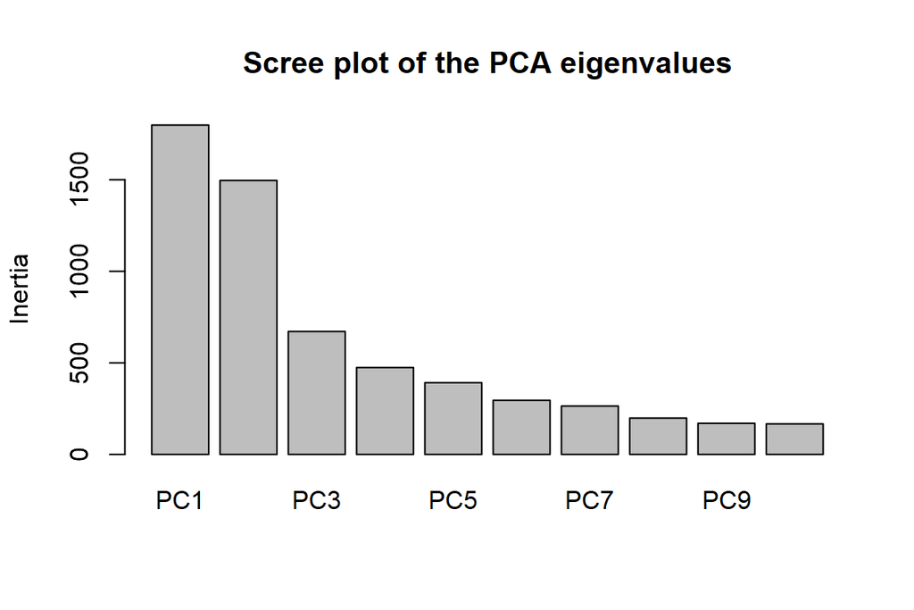

```r
pca <- rda(geno_pop_maf, scale=T)

# Scree plot of the PCA eigenvalues
screeplot(pca, type = "barplot", npcs=10, main="Scree plot of the PCA eigenvalues")
```

We plot the PCA performed on **population-based allele frequencies not filtered for MAF** and the figure is stored in `PCAplot.pdf`.

```r
# we load the dataset which gives the main gene pool of each population
gp <- readRDS(here("data/genomic_data/main_gp_info.rds"))$pop_level %>% arrange(Population)

GPs <- gp$main_gp_pop %>% as.factor()
bg <- gp %>%
  dplyr::select(main_gp_pop, main_gp_pop_color) %>%
  distinct() %>%
  arrange(main_gp_pop) %>%
  pull(main_gp_pop_color)

pdf(width=10,here("figs/RDA/PCAplot.pdf"))
lapply(list(c(1,2),c(3,4),c(5,6)), function(x){
  plot(pca, type="n", scaling=3, choices=x,
       xlab=paste0("PC",x[[1]]," (",round(summary(eigenvals(pca))[2,x[[1]]]*100,2),"%)"),
       ylab=paste0("PC",x[[2]]," (",round(summary(eigenvals(pca))[2,x[[2]]]*100,2),"%)"))
  points(pca, display="sites", pch=21, cex=1.3, col="gray32", scaling=3,
         bg=bg[GPs], choices=x)
  if(x[[1]]==1) legend("topleft", legend=levels(GPs), bty="n", col="gray32", pch=21, cex=1, pt.bg=bg)
recordPlot()})
dev.off()
```

Based on the scree plot and the PCA plots, we have to retain a given number of PCs to account for neutral population structure in downstream analyses:

```r
nb_PCscores <- 3
```

**How many axes do you want to keep to account for population structure in the RDA? In the following analyses, I kept the first 3 PCs.**

```r
df <- scores(pca, choices=c(1:nb_PCscores), display="sites", scaling="none") %>%
  as.data.frame() %>%
  rownames_to_column("pop") %>%
  inner_join(df, by="pop")
```

# 3 Variance partitioning

We want to disentangle the *relative contribution* of different factors in explaining genetic variation, namely:

- **climate**
- **neutral population structure**, captured by the first 3 PC scores from the **population-based allele frequencies**.
- **geography**, accounted for by the population coordinates (longitude and latitude) or by distance-based Moran’s eigen vector maps.

We run:

- one *full* RDA with all factors (population structure, climate and geographical distance), i.e. no variable conditioning.
- three *partial* RDA in which the factor of interest is conditioned by the other two factors.

```r
# Function to partition the variance
# ==================================

var_part <- function(df_geno, select_clim_var, df_var, scale_rda, center_rda, geography, nb_dbMEMs){

# The df of the explanatory variables has to include only the variables included in the model
df_var <- df_var %>%
  dplyr::select(all_of(select_clim_var),
                starts_with("Q"),
                starts_with("PC"),
                ends_with("itude"),
                contains("MEM"),
                -altitude)


# Build formulas of the RDA models
# ================================
form_clim_var <- paste(select_clim_var,collapse= " + ") # climatic variables
form_pgs_var <- colnames(df_var) %>% stringr::str_subset("^Q|^PC") %>%  paste(collapse= " + ") # pop structure

if(geography=="coordinates"){
  form_geo_var <- colnames(df_var) %>% stringr::str_subset("itude") %>%  paste(collapse= " + ") # coordinates
} else {
  form_geo_var <- colnames(df_var) %>%
    stringr::str_subset("MEM") %>%
   `[`(1:nb_dbMEMs) %>% # keep only the n first MEMs
    paste(collapse= " + ") # coordinates
}

# complete model formulas
form_full_rda <- paste("df_geno ~ ",
                       paste(c(form_clim_var,form_pgs_var,form_geo_var),collapse=" + " )) %>%
  as.formula()

form_clim_rda <- paste("df_geno ~ ",
                       form_clim_var,"+ Condition(",paste(c(form_pgs_var,form_geo_var),collapse=" + " ), ")") %>%
  as.formula()

form_pgs_rda <- paste("df_geno ~ ",
                       form_pgs_var,"+ Condition(",paste(c(form_clim_var,form_geo_var),collapse=" + " ), ")") %>%
  as.formula()

form.geo_rda <- paste("df_geno ~ ",
                       form_geo_var,"+ Condition(",paste(c(form_clim_var,form_pgs_var),collapse=" + " ), ")") %>%
  as.formula()


# Run the RDA models
# ==================

# Full RDA
full_rda <- rda(form_full_rda,
                data=df_var,
                scale=scale_rda,
                center=center_rda)
anova_full_rda <- anova(full_rda)

# Partial RDA: pure climatic model
clim_rda <- rda(form_clim_rda,
                data=df_var,
                scale=scale_rda,
                center=center_rda)
anova_clim_rda <- anova(clim_rda)

# Partial RDA: pure neutral population structure model
pgs_rda <- rda(form_pgs_rda,
               data=df_var,
               scale=scale_rda,
               center=center_rda)
anova_pgs_rda <- anova(pgs_rda)

# Partial RDA: pure geography model
geo_rda <- rda(form.geo_rda,
               data=df_var,
               scale=scale_rda,
               center=center_rda)
anova_geo_rda <- anova(geo_rda)


# Summary table
# =============

sum_tab_RDA <- tibble("RDA models"=c("Full model: Y ~ clim + geo + pgs.",
                      "Pure climate model: Y ~ clim | (geo + pgs)",
                      "Pure pop. gen. structure model: Y ~ pgs | (geo + clim)",
                      "Pure geography model: Y ~ geo | (pgs + clim)"),
       "Total exp. variance"=c(RsquareAdj(full_rda)[[1]],
              RsquareAdj(clim_rda)[[1]],
              RsquareAdj(pgs_rda)[[1]],
              RsquareAdj(geo_rda)[[1]]),
       "Relative exp. variance"=c(1,
                                  RsquareAdj(clim_rda)[[1]]/RsquareAdj(full_rda)[[1]],
                                  RsquareAdj(pgs_rda)[[1]]/RsquareAdj(full_rda)[[1]],
                                  RsquareAdj(geo_rda)[[1]]/RsquareAdj(full_rda)[[1]]),
       "P-value"=c(anova_full_rda[["Pr(>F)"]][[1]],
                   anova_clim_rda[["Pr(>F)"]][[1]],
                   anova_pgs_rda[["Pr(>F)"]][[1]],
                   anova_geo_rda[["Pr(>F)"]][[1]]))

# Export the table in latex
xtable(sum_tab_RDA, type = "latex",digits=2) %>%
  print(file = here(paste0("tables/variance_partitioning_RDA_",geography,".tex")), include.rownames=FALSE)

return(sum_tab_RDA)
}
```

```r
# Proxies of geography
geography <- c("coordinates","dbMEMs")

# number of distance-based Moran’s Eigenvector Maps (dbMEMs)
nb_dbMEMs <- 4
```

```r
lapply(geography, function(x){

  var_part <- var_part(df_geno=geno_pop, # we use the genomic data without MAF
                       select_clim_var=clim_var,
                       df_var=df,
                       scale_rda=F,center_rda=F,
                       geography = x,
                       nb_dbMEMs = nb_dbMEMs)

}) %>%
  setNames(geography) %>%
   saveRDS(file=here(paste0("outputs/RDA/variance_partitioning.rds")))
```

Variance partitioning with geographical coordinates (i.e. latitude and longitude) as proxies of geography.

```r
readRDS(file=here("outputs/RDA/variance_partitioning.rds"))[[1]] %>%
  kable_mydf(boldfirstcolumn = T)
```

| RDA models | Total exp. variance | Relative exp. variance | P-value |
| --- | --- | --- | --- |
| Full model: Y ~ clim + geo + pgs. | 0.65 | 1.00 | 0 |
| Pure climate model: Y ~ clim \| (geo + pgs) | 0.07 | 0.11 | 0 |
| Pure pop. gen. structure model: Y ~ pgs \| (geo + clim) | 0.17 | 0.27 | 0 |
| Pure geography model: Y ~ geo \| (pgs + clim) | 0.03 | 0.04 | 0 |

Variance partitioning with distance-based Moran’s Eigenvector Maps (dbMEMs) as proxies of geography.

```r
readRDS(file=here("outputs/RDA/variance_partitioning.rds"))[[2]] %>%
  kable_mydf(boldfirstcolumn = T)
```

| RDA models | Total exp. variance | Relative exp. variance | P-value |
| --- | --- | --- | --- |
| Full model: Y ~ clim + geo + pgs. | 0.67 | 1.00 | 0 |
| Pure climate model: Y ~ clim \| (geo + pgs) | 0.05 | 0.08 | 0 |
| Pure pop. gen. structure model: Y ~ pgs \| (geo + clim) | 0.09 | 0.14 | 0 |
| Pure geography model: Y ~ geo \| (pgs + clim) | 0.05 | 0.07 | 0 |

# 4 Identifying loci under selection

## 4.1 Run the RDA

We perform RDA models accounting or not for the neutral genetic population structure.

RDA summary statistics are summarized in the pdfs `RDAsummary.pdf` and the RDA plots colored by gene pool are shown in the pdfs `RDAplots.pdf`.

```r
# =========
# FUNCTIONS
# =========


# Function to create a S3 object with the RDA model and some info
# ===============================================================
new_RDA <- function(form_rda,selected_var,PCs,mod_rda,r2,eigenvalues,model_significance,axis_significance,vif){

  structure(
    .Data = list(form_rda=form_rda,
                 selected_var=selected_var,
                 PCs=PCs,
                 mod_rda=mod_rda,
                 r2=r2,
                 eigenvalues=eigenvalues,
                 model_significance=model_significance,
                 axis_significance=axis_significance,
                 vif=vif),
    creation_time = Sys.time(),
    class = "myrda"
  )
  }



# Function to print S3 object of class 'myrda'
# ============================================
print.myrda <- function(x,...){

  print_message <- c(
    paste0("  RDA formula: ", x$form_rda),
    paste0("  Creation time: ", format(attr(x, "creation_time"))),
    paste0(c("  List elements:", names(x)),collapse="   ")
    )

  cat(
    print_message,
    sep = "\n"
  )

}


# Function to run the RDA models and store the info in a S3 object of class 'myrda'
# =================================================================================
runRDA <- function(df,geno_pop,selected_var,pop_structure_correction){



  # write RDA formulas
form_clim_var <- paste(selected_var,collapse= " + ")
if(pop_structure_correction==T) {
  PCs <- colnames(df) %>% stringr::str_subset("^PC")
  form_pgs_var <- PCs %>%  paste(collapse= " + ")
  form_rda <- paste("geno_pop ~ ", form_clim_var,"+ Condition(",paste(c(form_pgs_var),collapse=" + " ), ")")
} else {
  PCs = NULL
  form_rda <- paste("geno_pop ~ ", form_clim_var)
  }
mod_rda <- rda(as.formula(form_rda), df)
r2 <- RsquareAdj(mod_rda)
eigenvalues <- summary(eigenvals(mod_rda, model = "constrained"))
model_significance <- anova.cca(mod_rda, parallel=getOption("mc.cores")) # default is permutation=999
axis_significance <- anova.cca(mod_rda, by="axis", parallel=getOption("mc.cores"))
vif <- vif.cca(mod_rda)

return(new_RDA(form_rda=form_rda,
               selected_var=selected_var,
               PCs=PCs,
               mod_rda=mod_rda,
               r2=r2,
               eigenvalues=eigenvalues,
               model_significance=model_significance,
               axis_significance=axis_significance,
               vif=vif))

}



# Function to generate a pdf with the RDA model outputs
# =====================================================
viz_RDAsummary <- function(x){

  # check the class of x
  stopifnot("x is not of class myrda" = class(x)=="myrda")

  # Generate R2 table
r2_tab <- x$r2 %>%
  as.data.frame() %>%
  pivot_longer(everything()) %>%
  column_to_rownames(var ="name") %>%
  round(2) %>%
  ggtexttable(rows = row.names(.),cols = NULL, theme = ttheme("blank"))

  # Generate table of eigenvalues and proportion of variance explained
eigenvalues_tab <- x$eigenvalues %>%
  as.data.frame() %>%
  round(2) %>%
  ggtexttable(rows = rownames(.), theme = ttheme("blank")) %>%
  tab_add_hline(at.row = 1:2, row.side = "top", linewidth = 2)

  # Generate table of model and axis significance
signi_tab <- bind_rows(as.data.frame(x$model_significance[-nrow(x$model_significance),]),
          as.data.frame(x$axis_significance[-nrow(x$axis_significance),])) %>%
  dplyr::mutate(across(!Df, ~ round(.x,3))) %>%
  ggtexttable(rows = rownames(.), theme = ttheme("blank")) %>%
  tab_add_hline(at.row = 1:2, row.side = "top", linewidth = 2) %>%
  tab_add_hline(at.row = 3, row.side = "top", linewidth = 0.01)

  # Generate table for VIF (Variance Inflation Factors)
vif_tab <- x$vif %>%
  as.data.frame() %>%
  round(2) %>%
  rownames_to_column("Variable") %>%
  pivot_wider(values_from=".", names_from = "Variable") %>%
  ggtexttable(rows = "VIF", theme = ttheme("blank")) %>%
  tab_add_hline(at.row = 2, row.side = "top", linewidth = 2)

  # Generate the screeplot of the eigenvalues
ggscreeplot <- x$eigenvalues %>% #
  as.data.frame() %>%
  dplyr::filter(row.names(.) == "Eigenvalue")  %>%
  pivot_longer(everything(),names_to="PC",values_to="eigenvalues") %>%
  ggplot(aes(x= PC,
             y=eigenvalues,
             group=1)) +
  geom_point(size=4)+
  geom_line() +
  ylab("Eigen values") + xlab("") +
  labs(title="Scree plot") +
  theme_bw()


ggarrange(ggarrange(r2_tab,signi_tab,vif_tab,nrow=3),
           ggarrange(eigenvalues_tab,ggscreeplot,nrow=2),
           nrow = 1,
           ncol = 2) %>%
annotate_figure(top = text_grob(x$form_rda,
                                size = 16,
                                color = 'black',
                                face = 'bold'))

}


# Function to plot the RDA models
# ==============================
plot_RDA <- function(df,x,GPs){

  # check the class of x
  stopifnot("x is not of class myrda" = class(x)=="myrda")

  if(x$axis_significance %>% as.data.frame() %>% nrow()-1>2) {
  par(mfrow=c(1,2))
  rdaplots <-  lapply(2:3, function(second_axis){
    plot(x$mod_rda, type="n", scaling=3, choices=c(1,second_axis))
    points(x$mod_rda, display="species", pch=20, cex=0.7, col="gray32", scaling=3, choices=c(1,second_axis))
    points(x$mod_rda, display="sites", pch=21, cex=1.3, col="gray32", scaling=3, bg=bg[GPs], choices=c(1,second_axis))
    text(x$mod_rda, scaling=3, display="bp", col="#0868ac", cex=1, choices=c(1,second_axis))
    if(second_axis==2) legend("topleft", legend=levels(GPs), bty="n", col="gray32", pch=21, cex=1, pt.bg=bg)
    recordPlot()
  })} else {
    par(mfrow=c(1,1))
    plot(x$mod_rda, type="n", scaling=3, choices=c(1,2))
    points(x$mod_rda, display="species", pch=20, cex=0.7, col="gray32", scaling=3, choices=c(1,2))
    points(x$mod_rda, display="sites", pch=21, cex=1.3, col="gray32", scaling=3, bg=bg[GPs], choices=c(1,2))
    text(x$mod_rda, scaling=3, display="bp", col="#0868ac", cex=1, choices=c(1,2))
    legend("bottomright", legend=levels(GPs), bty="n", col="gray32", pch=21, cex=1, pt.bg=bg)
  }

  title(x$form_rda, line=-3,outer = TRUE)
}
```

```r
# We store in a list the four combinations of:
  # - the two sets of selected climatic variables
  # - correction or not by population structure
rda_combinations <- list(
  list(selected_var = clim_var,
       pop_structure_correction = FALSE),
  list(selected_var = clim_var,
       pop_structure_correction = TRUE))


# Run the RDA models and store their information
rda_models <- lapply(rda_combinations, function(x){
  runRDA(df = df,
         geno_pop = geno_pop,
         selected_var = x$selected_var,
         pop_structure_correction = x$pop_structure_correction)})

# save the RDA models and their information
saveRDS(rda_models, here("outputs/RDA/RDAmodels.rds"))

# viz RDA models and their summary information
pdf(width = 13, height = 6, here("figs/RDA/RDAsummary.pdf"))
lapply(rda_models, viz_RDAsummary)
dev.off()

# plot RDA models
pdf(width = 12, height = 8, here("figs/RDA/RDAplots.pdf"))
lapply(rda_models, function(x) plot_RDA(df=df,x=x,GPs=GPs))
dev.off()
```

```r
rda_models <- readRDS(here("outputs/RDA/RDAmodels.rds"))
```

## 4.2 Identify outliers

Different methods can be used to identify the outliers with the RDA.

Outliers can be identified based on their *extremeness* along a *distribution of Mahalanobis distances* estimated between each locus and the center of the RDA space using a certain number of axes (K). The Mahalanobis distances are calculated with the `rdadapt` function from Capblancq and Forester (2021), which returns $p$-values and $q$-values for each SNP. Different thresholds can then be used to identify the outliers:

- Capblancq et al. (2020) uses a $p$-value threshold with a Bonferroni correction to account for multiple testing: $p$-value < 0.01 / number of SNPs (see [code](https://github.com/Capblancq/Local-Adaptation-Fagus-sylvatica)).
- Capblancq and Forester (2021) ([code](https://github.com/Capblancq/RDA-landscape-genomics)) rank-ordered the SNPs based on their $p$-values (the $p$-value of a given SNP captures how far its Mahalanobis distance is from the distribution of Mahalanobis distances of all SNPs) and identified the 0.2% or 0.5% of the SNPs with the lowest $p$-values
- we can also use a FDR (False Discovery Rate) threshold of 5% or 10% to identify outliers as the `rdadapt` function returns both $p$-values and $q$-values (see François et al. (2016)).

Outliers can also been identified based on the *extreme loadings on each retained axis*. Method used in Forester et al. (2018) (see [code](https://popgen.nescent.org/2018-03-27_RDA_GEA.html), in which a 3 standard deviation cutoff is used (two-tailed $p$-value = 0.0027).

**In the present document, I left the different ways of identifying the candidate SNPs but in the following analyses, we will only use the candidate SNPs identified based on the Mahalanobis distances and with a FDR threshold of 5%.**

```r
# ====================================
# Function to identify the outlier SNPs
# =====================================

identify_outliers <- function(rda_model, explanatory_data, geno_data){

# outlier detection based on  extreme Mahalanobis distances from the RDA center
# =============================================================================

# Genome scan with K = 2 (degrees of freedom of the X2 distribution)
  # rdadapt is a function to conduct a RDA based genome scan (from Capblancq & Forester 2021)
GSout <- rdadapt(rda_model$mod_rda, 2) %>%
  as_tibble() %>%
  mutate(snp=colnames(geno_data))

# P-values threshold after Bonferroni correction
# outliers_maha <- GSout %>%
#   filter(pvalues <  0.01/nrow(.)) %>%
#   mutate(maha_meth = TRUE) %>%
#   dplyr::select(snp,maha_meth) # we do not keep the p.values and q.values in the outlier table

# FDR threshold of 5%
outliers_maha <- GSout %>%
  filter(qvalues <  0.05) %>%
  mutate(maha_meth = TRUE) %>%
  dplyr::select(snp,maha_meth) # we do not keep the p.values and q.values in the outlier table

# P-values are rank-ordered and we select the 0.5% with the lowest p-values
# outliers_maha <- GSout %>%
#   arrange(pvalues) %>%
#   slice(1:(0.005*nrow(.))) %>%
#   mutate(maha_meth = TRUE) %>%
#   dplyr::select(snp,maha_meth) # we do not keep the p.values and q.values in the outlier table


# outlier detection based on  extreme axis loadings
# =================================================

# As we identify the SNPs that has loadings along the significant axes,
# we first extract the number of significant axes
nb_signi_axis <- rda_model$axis_significance %>%
  as.data.frame() %>%
  dplyr::rename(pvalue="Pr(>F)") %>%
  dplyr::filter(pvalue<0.05) %>%
  nrow()

loads <- scores(rda_model$mod_rda, choices=c(1:(nrow(as.data.frame(rda_model$axis_significance))-1)), display="species")


outliers_loads <- lapply(1:nb_signi_axis, function(id.axis){
  out <- detectoutliers(loads[,id.axis],3) # function to identify outliers based on their RDA loadings (from  Forester et al. 2018)
  tibble(
    #axis=rep(id.axis,times=length(out)), # we do not keep the information about the axis
    snp = names(out),
    load_meth = TRUE,
    # loading = out # we do not keep the loadings
  )
}) %>%
  list_rbind() %>%
  distinct()



# Merge outliers identified by the two methods
# ============================================

all_outliers <- full_join(outliers_maha,outliers_loads, by="snp") %>%
  mutate(across(c(maha_meth,load_meth), ~replace_na(.,FALSE)))

all_outliers <- map(all_outliers$snp, function(snp){
 cordf <-  cor(explanatory_data[,names(rda_model$vif)],geno_data[,snp]) %>%
    as.data.frame() %>%
    rownames_to_column() %>%
    pivot_wider(names_from="rowname", values_from = "V1") %>%
     mutate(max_var = names(which.max(abs(.)))) %>%
     mutate(max_var_clim = names(which.max(abs(.[,rda_model$selected_var]))))
}) %>%
  setNames(all_outliers$snp) %>%
  list_rbind(names_to = "snp") %>%
  inner_join(all_outliers,by="snp")


list(rda_model = rda_model,
     GSout = GSout, # keep the p.values for the Manhattan plot
     outliers = all_outliers)

}
```

```r
# we identify the outlier SNPs for the four RDA models
rda_outliers <- rda_models %>%
  lapply(function(x) {
    identify_outliers(rda_model = x, explanatory_data = df, geno_data = geno_pop)
  })

saveRDS(rda_outliers, here("outputs/RDA/RDA_outliers.rds"))
```

## 4.3 Outlier visualization

### 4.3.1 RDA plots based on Forester et al. (2018)

We visualize the outliers with RDA plots following Forester et al. (2018) (see [code](https://popgen.nescent.org/2018-03-27_RDA_GEA.html)). Figures are stored in `RDAplots_outliers_1.pdf`.

```r
# Function to make one RDA plot with different colors for outlier SNPs
make_one_outlier_rda_plot <- function(mod_rda, data_plots, xlim, ylim, second_axis,arrow_length,outline_col){

plot(mod_rda, type="n", scaling=3, xlim=xlim, ylim=ylim, choices=c(1,second_axis))
points(mod_rda, display="species", pch=21, cex=1, col=data_plots$allsnps$nooutlier_color, bg=data_plots$allsnps$nooutlier_bg , scaling=3, choices=c(1,second_axis))
points(mod_rda, display="species", pch=21, cex=1, col=data_plots$allsnps$outlier_color, bg=data_plots$allsnps$outlier_bg, scaling=3, choices=c(1,second_axis))
text(mod_rda, scaling=3, display="bp", col="#0868ac", cex=1, arrow.mul=arrow_length, choices=c(1,second_axis))
legend("topleft", legend=data_plots$legend_names, bty="n", col=outline_col, pch=21, cex=1, pt.bg=data_plots$legend_colors,ncol=1,title=data_plots$legend_title)
recordPlot()

}




# Function that combines two types of plot:
  # plots in which outliers are colored according to their most associated climatic variable
  # plots in which outliers are colored according to the detection method used to identify them:
      # a method based on the Mahalanobis distances from the center of the RDA space
      # a method based on the extreme SNP loadings on each significant axis
combine_rda_outlier_plots <- function(rda_out,color_clim_var){

# Storing data and options to generate the plots in a list
list_data_plots <- list(clim=list(), # options/data specific to plots with colors based on the climatic variables
                        meth=list()) # options/data specific to plots with colors based on the detection methods


# Figure options shared between the two types of plot
# ===================================================

nooutliers_bg <- '#f1eef6'
outline_col <- 'gray32'
transparent_col <- rgb(0,1,0, alpha=0)



# Fig options/data specific to plots based on the climatic variables
# ==================================================================

# Attribute one color to each climatic variable
selected_var_colors <- tibble(max_var_clim = names(color_clim_var),
                              outlier_bg = color_clim_var) %>%
  dplyr::filter(max_var_clim %in% rda_out$rda_model$selected_var)

# Generate a dataframe with color information for outliers
outlier_colors <-  rda_out$outliers %>%
  dplyr::select(snp, max_var_clim) %>%
  left_join(selected_var_colors, by="max_var_clim")

# Generate a dataframe with color information for all SNPs
list_data_plots$clim$allsnps <- tibble(snp=rownames(rda_out$rda_model$mod_rda$CCA$v)) %>%
  left_join(outlier_colors, by="snp") %>%
  mutate(outlier_bg = replace_na(outlier_bg,transparent_col),
         outlier_color = ifelse(outlier_bg == transparent_col, transparent_col, outline_col),
         nooutlier_bg = ifelse(outlier_bg == transparent_col, nooutliers_bg, transparent_col),
         nooutlier_color = ifelse(outlier_bg == transparent_col, outline_col, transparent_col))

# Legend options
list_data_plots$clim$legend_title <- 'Climatic variable'
list_data_plots$clim$legend_names <- selected_var_colors$max_var_clim
list_data_plots$clim$legend_colors <- selected_var_colors$outlier_bg


# Fig options/data specific to plots based on the detection methods
# =================================================================

# Attribute one color to each method
method_colors <- c('#FCF926','#3BCD24','#CD24B2') %>% setNames(c("Mahalanobis distance","Axis loadings", "Both"))

# Legend options
list_data_plots$meth$legend_colors <- method_colors
list_data_plots$meth$legend_names <- names(method_colors)
list_data_plots$meth$legend_title <- 'Outlier detection method'


# attribute colors to all SNPs
list_data_plots$meth$allsnps <-  tibble(snp=rownames(rda_out$rda_model$mod_rda$CCA$v)) %>%
  left_join(rda_out$outliers[,c("snp", "load_meth", "maha_meth")],by="snp") %>%
  mutate(outlier_bg = case_when(load_meth == TRUE & maha_meth == TRUE ~ method_colors["Both"],
                                load_meth == TRUE & maha_meth == FALSE ~ method_colors["Axis loadings"],
                                load_meth == FALSE & maha_meth == TRUE ~ method_colors["Mahalanobis distance"],
                                is.na(load_meth) & is.na(maha_meth) ~ transparent_col),
         outlier_color = ifelse(outlier_bg == transparent_col, transparent_col, outline_col),
         nooutlier_bg = ifelse(outlier_bg == transparent_col, nooutliers_bg, transparent_col),
         nooutlier_color = ifelse(outlier_bg == transparent_col, outline_col, transparent_col))


# Generate the RDA plots
# =====================

# For RDA models with 2 explanatory variables, we can only plot RDA1 vs RDA2

if(rda_out$rda_model$axis_significance %>% as.data.frame() %>% nrow()-1>2) { # rda models with more than 2 climatic variables

par(mfrow=c(2,2))
lapply(2:3, function(second_axis){ # generate two plots: RDA1 vs RDA2 and RDA1 vs RDA3
    lapply(list_data_plots, function(x) make_one_outlier_rda_plot(mod_rda = rda_out$rda_model$mod_rda,
                                                                  data_plots = x,
                                                                  xlim=c(-1,1),
                                                                  ylim=c(-0.5,0.5),
                                                                  arrow_length=1.25,
                                                                  outline_col=outline_col,
                                                                  second_axis=second_axis))

  })} else {  # rda models with 2 climatic variables

par(mfrow=c(1,2))
    lapply(list_data_plots, function(x) make_one_outlier_rda_plot(mod_rda = rda_out$rda_model$mod_rda,
                                                                  data_plots = x,
                                                                  xlim=c(-0.3,0.3),
                                                                  ylim=c(-0.5,0.5),
                                                                  outline_col=outline_col,
                                                                  arrow_length=0.6,
                                                                  second_axis=2))

  }

  title(rda_out$rda_model$form_rda, line=-3,outer = TRUE) # rda model formula as title

}
```

```r
# Plot RDA outliers with different colors based either on the detection method or the most associated climatic variable
pdf(width = 12, height = 8, here("figs/RDA/RDAplots_outliers_1.pdf"))
lapply(rda_outliers, function(x) combine_rda_outlier_plots(rda_out = x,color_clim_var = color_clim_var))
dev.off()
```

### 4.3.2 RDA plots based on Capblancq and Forester (2021)

We visualize the outliers with RDA and Manhattan plots following Capblancq and Forester (2021) ([code](https://github.com/Capblancq/RDA-landscape-genomics)). Figures are stored in `RDAplots_outliers_2.pdf`.

```r
make_rda_ggplot <- function(data_plots,TAB_var){

  data_plots$tab[order(data_plots$tab$snp_type),] %>%
  ggplot() +
  geom_hline(yintercept=0, linetype="dashed", color = gray(.80), linewidth=0.6) +
  geom_vline(xintercept=0, linetype="dashed", color = gray(.80), linewidth=0.6) +
  geom_point(aes(x=RDA1*20, y=RDA2*20, colour = snp_type), size = 1.4) +
  scale_color_manual(values = data_plots$legend_colors) +
  geom_segment(data = TAB_var, aes(xend=RDA1, yend=RDA2, x=0, y=0),
               colour="black", linewidth=0.15, linetype=1, arrow=arrow(length = unit(0.02, "npc"))) +
  geom_text(data = TAB_var, aes(x=1.1*RDA1, y=1.1*RDA2, label = row.names(TAB_var)), size = 2.5) +
  xlab("RDA 1") + ylab("RDA 2") +
  facet_wrap(~"RDA space") +
  guides(color=guide_legend(title=data_plots$legend_title)) +
  theme_bw(base_size = 11) +
  theme(panel.background = element_blank(),
        legend.background = element_blank(),
        panel.grid = element_blank(),
        plot.background = element_blank(),
        legend.text=element_text(size=rel(.8)),
        strip.text = element_text(size=11))



}

make_manhattan_plot <- function(data_plots){

data_plots$tab[order(data_plots$tab$snp_type),] %>%
ggplot() +
  geom_hline(yintercept=-log10(0.01/length(data_plots$tab$pvalues)), linetype="dashed", color = gray(.80), linewidth=0.6) +
  geom_point(aes(x=pos, y=-log10(pvalues), col = snp_type), size=1.4) +
  scale_color_manual(values = data_plots$legend_colors) +
  xlab("Loci") + ylab("-log10(p-values)") +
  facet_wrap(~"Manhattan plot", nrow = 3) +
  guides(color=guide_legend(title=data_plots$legend_title)) +
  theme_bw(base_size = 11) +
  theme(legend.position="right", legend.background = element_blank(), panel.grid = element_blank(), legend.box.background = element_blank(), plot.background = element_blank(), panel.background = element_blank(), legend.text=element_text(size=rel(.8)), strip.text = element_text(size=11))
  }


# Function that combines two types of plot:
  # plots in which outliers are colored according to their most associated climatic variable
  # plots in which outliers are colored according to the detection method used to identify them:
      # a method based on the Mahalanobis distances from the center of the RDA space
      # a method based on the extreme SNP loadings on each significant axis
combine_rda_outlier_ggplots <- function(rda_out,color_clim_var){

# Storing data and options to generate the plots in a list
list_data_plots <- list(clim=list(), # options/data specific to plots with colors based on the climatic variables
                        meth=list()) # options/data specific to plots with colors based on the detection methods


# Figure options shared between the two types of plot
# ===================================================

nooutliers_bg <- "gray90"
nooutliers_legend <- "No detection"

locus_scores <- scores(rda_out$rda_model$mod_rda, choices=c(1:2),
                       display="species", # 'species' in the vegan package correspond to the loci
                       scaling="none") %>%
  as.data.frame() %>%
  rownames_to_column("snp") %>%
  as_tibble() %>%
  inner_join(rda_out$GSout, by="snp") %>%
  mutate(pos=seq(1:nrow(.)))

TAB_var <- as.data.frame(scores(rda_out$rda_model$mod_rda, choices=c(1,2), display="bp"))

# Fig options/data specific to plots based on the climatic variables
# ==================================================================

# Legend options
vec_color_clim_var <- color_clim_var[names(color_clim_var) %in% unique(rda_out$outliers$max_var_clim)]
list_data_plots$clim$legend_title <- 'Climatic variable'
list_data_plots$clim$legend_names <- c(nooutliers_legend,names(vec_color_clim_var))
list_data_plots$clim$legend_colors <- c(nooutliers_bg,vec_color_clim_var) %>% unname()


list_data_plots$clim$tab <-  locus_scores %>%
  left_join(rda_out$outliers[,c("snp", "max_var_clim")],by="snp") %>%
  mutate(max_var_clim = replace_na(max_var_clim,nooutliers_legend)) %>%
  mutate(max_var_clim =factor(max_var_clim,levels=list_data_plots$clim$legend_names)) %>%
  dplyr::rename(snp_type = max_var_clim)


# Fig options/data specific to plots based on the detection methods
# =================================================================


# Legend options
list_data_plots$meth$legend_colors <- c(nooutliers_bg,'#FCF926','#3BCD24','#CD24B2')
list_data_plots$meth$legend_names <- c(nooutliers_legend,"Mahalanobis distance","Axis loadings", "Both")
list_data_plots$meth$legend_title <- 'Outlier detection'


list_data_plots$meth$tab <-   locus_scores %>%
  left_join(rda_out$outliers[,c("snp", "load_meth", "maha_meth")],by="snp") %>%
  mutate(snp_type = case_when(load_meth == TRUE & maha_meth == TRUE ~  list_data_plots$meth$legend_names[[4]],
                              load_meth == TRUE & maha_meth == FALSE ~ list_data_plots$meth$legend_names[[3]],
                              load_meth == FALSE & maha_meth == TRUE ~ list_data_plots$meth$legend_names[[2]],
                              is.na(load_meth) & is.na(maha_meth) ~ list_data_plots$meth$legend_names[[1]])) %>%
  mutate(snp_type=factor(snp_type,levels=list_data_plots$meth$legend_names))



# Generate the RDA plots
# =====================


p1 <- lapply(list_data_plots, function(x) make_rda_ggplot(data_plots = x,
                                                         TAB_var=TAB_var))

p2 <- lapply(list_data_plots, function(x) make_manhattan_plot(data_plots = x))

plot_row <- plot_grid(p1$clim, p1$meth,p2$clim,p2$meth, ncol=2)

# Title options
title <- ggdraw() +
  draw_label(
    rda_out$rda_model$form_rda,
    fontface = 'bold',
    x = 0,
    hjust = 0
  ) +
  theme(
    # add margin on the left of the drawing canvas,
    # so title is aligned with left edge of first plot
    plot.margin = margin(0, 0, 0, 7)
  )

# merge title and plots
plot_grid(
  title, plot_row,
  ncol = 1,
  # rel_heights values control vertical title margins
  rel_heights = c(0.1, 1)
)


}
```

```r
# Plot RDA outliers with different colors based either on the detection method or the most associated climatic variable
pdf(width = 12, height = 8, here("figs/RDA/RDAplots_outliers_2.pdf"))
lapply(rda_outliers, function(x) combine_rda_outlier_ggplots(rda_out = x, color_clim_var=color_clim_var))
dev.off()
```

**Comments:**

For RDA not corrected for population structure, in the RDA plots with RDA1 in the x-axis and RDA2 in the y-axis, some outlier SNPs identified with the SNP loadings are the middle of the cloud of SNPs. This is due to the 3 significant axes in this model. Indeed, in this model, most outlier SNPs were identified based on the third axis and that’s why they show up in the middle of the SNP cloud when we plot them along the first two axes of the RDA.

This is not the case for the RDA model corrected for population structure as there were only 2 significant axes in this model.

**Note that for the following analyses, we will only use the candidate SNPs identified with the Mahalanobis distances and with a FDR threshold of 5% (so the SNPs that show up in the middle of the cloud will not be selected).**

## References

Capblancq, Thibaut, and Brenna R Forester. 2021. “Redundancy Analysis (RDA): A Swiss Army Knife for Landscape Genomics.” *Methods in Ecology and Evolution*.

Capblancq, Thibaut, Susanne Lachmuth, Matthew C Fitzpatrick, and Stephen R Keller. 2023. “From Common Gardens to Candidate Genes: Exploring Local Adaptation to Climate in Red Spruce.” *New Phytologist* 237 (5): 1590–1605.

Capblancq, Thibaut, Xavier Morin, Maya Gueguen, Julien Renaud, Stéphane Lobreaux, and Eric Bazin. 2020. “Climate-Associated Genetic Variation in Fagus Sylvatica and Potential Responses to Climate Change in the French Alps.” *Journal of Evolutionary Biology* 33 (6): 783–96.

Forester, Brenna R, Jesse R Lasky, Helene H Wagner, and Dean L Urban. 2018. “Comparing Methods for Detecting Multilocus Adaptation with Multivariate Genotype–Environment Associations.” *Molecular Ecology* 27 (9): 2215–33.

François, Olivier, Helena Martins, Kevin Caye, and Sean D Schoville. 2016. “Controlling False Discoveries in Genome Scans for Selection.” *Molecular Ecology* 25 (2): 454–69.